# Problem Set 06: Confidence Intervals (30 pts)

Authorized Resources: Anyone and anything.

# Introduction

In this problem set we will use a small **sample** of data from the [General Social Survey](http://gss.norc.org/). The survey is designed to monitor changes in both social characteristics and attitudes. You will work with a **sample** from one neighborhood. The full neighborhood of **ALL individuals** is the population. For this problem set we do **not** know the **true population parameters** for any of the variables, because we do not have data on every person in the neighborhood. This is different from problem set 5 as we are using a sample of data.

## Markdown File

Just like the first problem set, you will create an rmarkdown file; you can refer to the first problem set for instruction. Name your file with the following format **PS06_lastname_firstname_section**

Fill in your answers to the exercises below with a corresponding exercise header in your rmarkdown file. Be sure to include text *and* code where necessary.

## Deliverable

- You will turn in your completed problem set as a **knitted pdf file** to Gradescope.
- Include a documentation statement.
- Each exercise is worth 3 points.
- Be sure to **make a header to label each Exercise**, this means using # followed by the word Exercise and the exercise number.
- Please type your code to answer the questions in a code chunk (gray part), under the exercise headers and type (**BRIEF**) answers to any interpretation questions in the white part under the headers.

## Setup

First load the necessary packages

```r
# Recall that loading the tidyverse "umbrella" package loads ggplot2, dplyr, and
# readr all at once. Feel free to load these packages any way you choose.
library(tidyverse)
library(moderndive)
library(infer)
```

Next load the data set, from where it is stored on the web:

```r
gss_sample <- read_csv("https://docs.google.com/spreadsheets/d/e/2PACX-1vSypSoDCMH2N76Vo2dZRPkw2q3t1mbvAXlOtgPDIsHg4NclAQFmER-BdvXH9_lrT40UQCVdPXOi_NMJ/pub?gid=257689625&single=true&output=csv")
```

Be sure to take a look at the data in the **viewer**. Each row in the data set is a person that was surveyed (100 rows or cases in total). The variables in the data set include each respondent’s `age`, `race`, and number of hours of TV watched a day `tvhours`.

# Confidence intervals from a bootstrap resample

## Step 1: Take 1000 bootstrap resamples

The following code tells R to take 1000 bootstrap resamples from the `gss_sample` data. Set the seed to 92!

```r
set.seed(92)

boot_samp_1000 <- gss_sample %>%
  rep_sample_n(size = 100, reps = 1000, replace = TRUE)
```

Note a few important details about the `rep_sample_n()` function, and bootstrap sampling in general:

- `size = 100` tells R that each bootstrap resample we take has 100 cases… the size of the original sample
- `reps = 1000` tells R to take 1000 bootstrap resamples (each of size 100).
- The `replace = TRUE` argument tells R that in each bootstrap resample, we can include a row from `gss_sample` multiple times. So if for instance, respondent # 12 is the first random resample taken here, respondent 12 is still available to be resampled **again** at random. Thus, some people may appear **multiple times** in our bootstrap resample, and some people from the original data set may not appear at all.
- We save the results in a data frame `boot_samp_1000`.

Take a look at the `boot_samp_1000` data frame we just generated in RStudio’s data viewer. Note that the `replicate` column labels each bootstrap resample (the first 100 rows are labeled 1, the next 100 rows are labeled 2, etc.)

1. How many rows does `boot_samp_1000` have? **Why?**

## Step 2: Calculate the bootstrap statistic

Let’s say we want to use the bootstrap resample that we just generated to calculate a confidence interval for the population mean $\mu_{tv}$ of `tvhours`. To do so, we need to know the sample mean $\bar{x}$ of `tvhours` **for each of the 1000 bootstrap resamples**. In this case, the sample mean $\bar{x}$ of `tvhours` for **each bootstrap resample** is our **BOOTSTRAP STATISTIC**. We can calculate that with two lines of code, like so:

```r
boot_distrib_tv <- boot_samp_1000 %>%
  group_by(replicate) %>%
  summarize(boot_stat = mean(tvhours))
```

Note that:

- The `group_by()` argument tells `R` to take the sample mean of `tvhours` **separately** for each different `replicate` in the bootstrap resample.
- We put the sample mean for each bootstrap resample in a column called `boot_stat`

> This is the bootstrap distribution for the mean of `tvhours`!

Take a look at the `boot_distrib_tv` we just created in RStudio’s data viewer.

1. How many values of the bootstrap statistic `boot_stat` are there? Please explain **why** there are this many values of the bootstrap statistic.

### Visualizing the bootstrap distribution

The bootstrap distribution is shown in the figure below. This is a histogram of the `boot_stat` values from `boot_distrib_tv`.

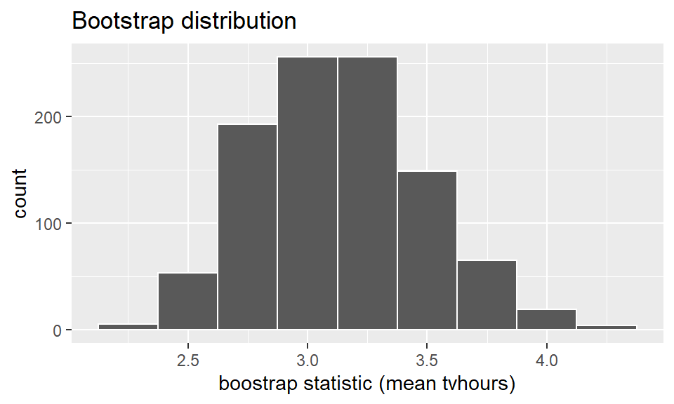

## Step 3: CI from a bootstrap resample

### a) CI using the standard error

We can now use the bootstrap distribution for the sample mean `tvhours` $\bar{x}$ to calculate a 95% confidence interval for the population mean `tvhours` $\mu_{tv}$, using the standard error method. This method assumes the bootstrap distribution is approximately normal. This interval is calculated as

$$\text{mean} \pm 1.96 \cdot
SD$$

The 1.96 comes from the standard normal distribution.

```r
qnorm(.975)
```

```
## [1] 1.959964
```

- The mean here would be the mean of the bootstrap distribution.
- The SD here is the standard deviation of the bootstrap distribution, which recall has a special name: the **standard error**.

We can thus apply the standard error method, like so:

```r
boot_distrib_tv %>%
  summarize(mean = mean(boot_stat),
            se = sd(boot_stat),
            lower_ci = mean - (qnorm(.975) * se),
            upper_ci = mean + (qnorm(.975) * se))
```

```
## # A tibble: 1 x 4
##    mean    se lower_ci upper_ci
##   <dbl> <dbl>    <dbl>    <dbl>
## 1  3.13 0.347     2.45     3.81
```

### b) CI using percentile method

You can also calculate a 95% confidence interval using the percentile method. The logic goes like this:

Since our bootstrap resample had 1000 values of `boot_stat`:

- 950 of the `boot_stat` values fall **inside** this 95% confidence interval, i.e. 95%
- 25 values fall **below** it. i.e. the lower 2.5%
- 25 values fall **above** it. i.e. the higher 2.5%

totaling 100%. We can use **the quantiles** of the bootstrap distribution to find these values like so:

```r
prct_ci_tv <- boot_distrib_tv %>%
  summarize(lower_ci = quantile(boot_stat, 0.025),
            upper_ci = quantile(boot_stat, 0.975))
```

```r
prct_ci_tv
```

```
## # A tibble: 1 x 2
##   lower_ci upper_ci
##      <dbl>    <dbl>
## 1     2.53     3.87
```

This method

- Asks `R` to identify the 0.025 quantile of the bootstrap sample means… this is the value **below** which **2.5% of the values of `boot_stat`** fall (or 25 cases in this example… 25/1000 = 0.025)
- Asks `R` to identify the 0.975 quantile for the bootstrap sample means… this is the value **above** which the other **2.5% of the values of `boot_stat`** fall (or 25 cases in this example 975/1000 = 0.975)
- The middle 95% of the values fall between these two quantiles

Based on these results, we are 95% confident that the **true mean hours of TV watched $\mu_{tv}$ in the population** is between the upper and lower CI we just calculated.

### Visualizing the Confidence interval

The bootstrap distribution and the 95% confidence intervals we just calculated are shown in the figure below. This is a histogram of the `boot_stat` values from `boot_distrib_tv`. The green line is the lower bound of the 95% CI, and the blue line is the upper bound. 950 of the 1000 bootstrap resamples had a mean for `tvhours` that fell **between** the green and blue lines…25 of the samples had a mean above the blue line, and 25 of the samples had a mean below the green line.

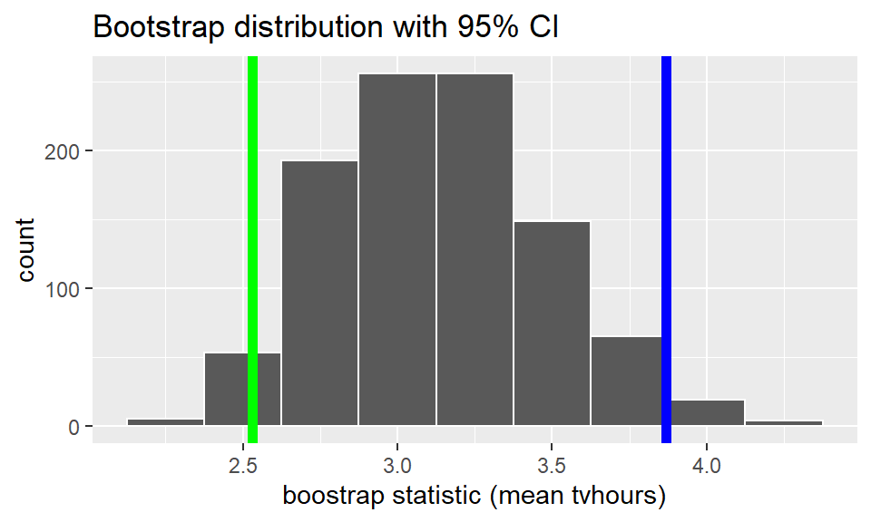

1. **If** we calculated a **90% confidence interval** for the mean of `tvhours` using this same bootstrap resample and the percentile method, roughly how many of the 1000 values of `tv_mean` would fall between the green and blue lines?
2. Use the bootstrap resampling distribution for `tvhours` generated above (`boot_distrib_tv`) and the **percentile** method to calculate a 99% confidence interval for the mean `tvhours`.
3. Which confidence interval is **WIDER**: the 95% confidence interval or the 99% confidence interval for the population mean `tvhours` $\mu_{tv}$? Why?

# Finding Confidence Intervals Using `Infer`

As we learning in the reading, the `infer` package provides a way to find confidence intervals. We used this package in many of our in-class notes.

1. Use the `infer` package and the the functions `specify()`, `generate()`, and `calculate()` to generate a bootstrap distribution for the variable `race`. Set the seed to 504. Success is `POC`. Use 1000 bootstrap replications.
2. Calculate a 90% confidence interval for the proportion of respondents that identify as `POC` using the **standard error** method.
3. Calculate a 90% confidence interval for the proportion of respondents that identify as `POC` using the **percentile** method.
4. Interpret the 90% **percentile** confidence interval.
5. Create a visualization, using the `infer` package, of the bootstrap sampling distribution. Discuss if it is appropriate to use the standard error method.

## Documenting software

- File creation date: 2022-07-06
- R version 4.1.3 (2022-03-10)
- `tidyverse` package version: 1.3.1
- `moderndive` package version: 0.5.4
- `infer` package version: 1.0.2